# 11.0 Portfolio assignment 11

20 min: Do a Numerical VS Categorical bivariate analysis on the penguins dataset.

- Choose one of the categorical columns: species, island or sex
- use .groupby('').mean() too look at the means of the numerical columns. Does it look like there is a difference between categories?
- Use the seaborn barplot to plot the mean and confidence. Create this plot for each of the numerical columns (bill_length_mm bill_depth_mm, flipper_length_mm, body_mass_g)
- For each of the plots, write a conclusion: Is there a statistically significant difference for this numerical column for each category?
- Optional: Repeat this proces for the other two categorical columns

```python
import pandas as pd
import seaborn as sns

penguins = sns.load_dataset("penguins")
```

[figure not shown]

## 11.1 Numerical means grouped by species

```python
penguins.groupby('species').mean()
```

| species | bill_length_mm | bill_depth_mm | flipper_length_mm | body_mass_g |
| --- | --- | --- | --- | --- |
| Adelie | 38.791391 | 18.346358 | 189.953642 | 3700.662252 |
| Chinstrap | 48.833824 | 18.420588 | 195.823529 | 3733.088235 |
| Gentoo | 47.504878 | 14.982114 | 217.186992 | 5076.016260 |

### 11.1.1 Observeringen

- Een Gentoo penguin is gemiddeld een stuk zwaarder dan de andere twee soorten penguins
- Een Adelie penguin heeft gemiddeld een kortere snavel dan de andere soorten
- Een Gentoo heeft een lange maar dunne snavel in vergelijking met de andere soorten
- Een Gentoo penguin heeft de langste flipper lengte van alle soorten

## 11.2 Barplot mean and confidence

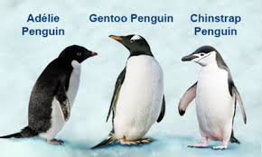

### 11.2.1 Lengte snavel vs Soort

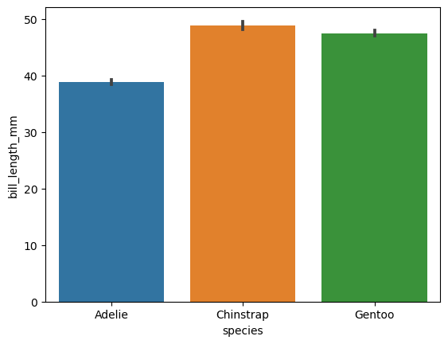

```python
sns.barplot(y="bill_length_mm", x="species", data=penguins)
```

#### 11.2.1.1 Observeringen

- Er is een overlap in confidence interval tussen de Chinstrap en Gentoo
  - Een meetwaarde tussen de interval is dus lastig te voorspellen (soort)
- Een Adelie penguin heeft gemiddeld een kortere snavel dan de andere soorten

### 11.2.2 Dikte snavel vs Soort

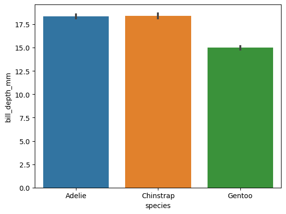

```python
sns.barplot(y="bill_depth_mm", x="species", data=penguins)
```

#### 11.2.2.1 Observeringen

- Er is een overlap in confidence interval tussen de Chinstrap en Adelie
  - Een meetwaarde tussen de interval is dus lastig te plaatsen (soort)
- Een Gentoo heeft een lange maar dunne snavel in vergelijking met de andere soorten

### 11.2.3 Lengte flipper vs Soort

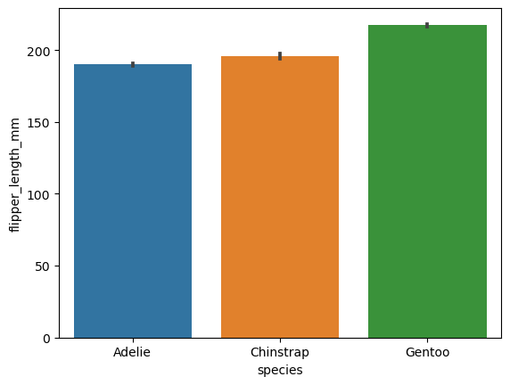

```python
sns.barplot(y="flipper_length_mm", x="species", data=penguins)
```

### 11.2.4 Lichaamsgewicht vs Soort

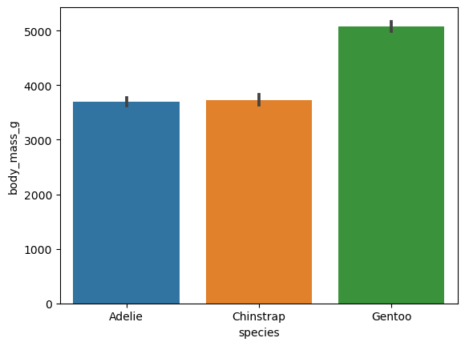

```python
sns.barplot(y="body_mass_g", x="species", data=penguins)
```

#### 11.2.4.1 Observeringen

- Er is een overlap in confidence interval tussen de Chinstrap en Adelie
  - Een meetwaarde tussen de interval is dus lastig te plaatsen (soort)
- Een Gentoo penguin is gemiddeld een stuk zwaarder dan de andere twee soorten penguins